# PCA-Parte 2

Pamela E. Pairo- AID 2022

21/05/2022

# Base de datos conocida

Se hace un sample de 200 datos (100 variadad 1, 100 variedad 2) de la base de datos original.

```r
df_vinos <- read_excel("vino.xlsx") %>%
  mutate_at('variedad', as.factor)
```

Nos quedamos con las variables numéricas

```r
df_numericas <-df_vinos %>%
      select(is.numeric)
```

## Boxplots para todas las variables

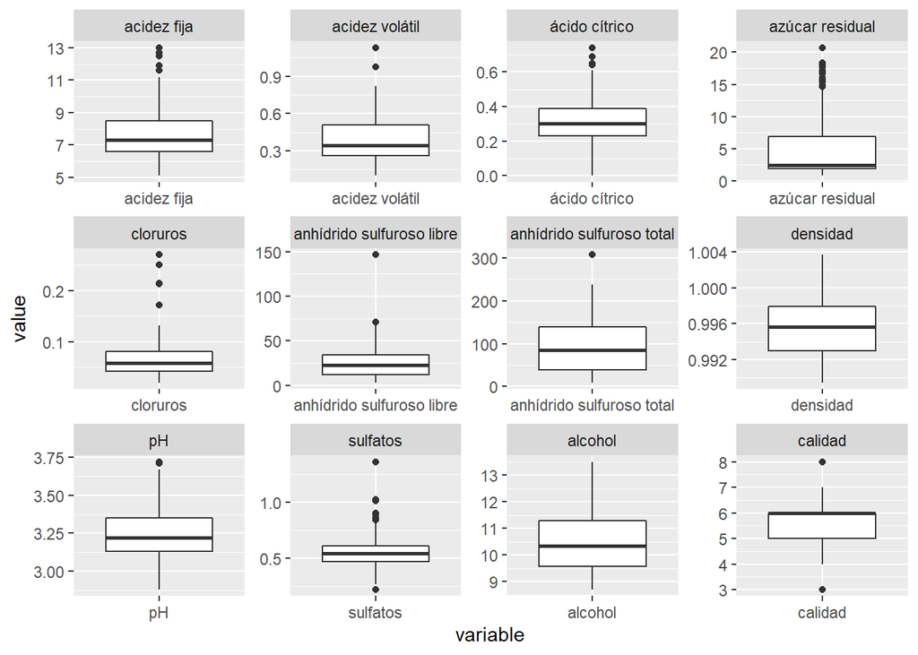

```r
data_long <- melt(df_vinos)
ggplot(data_long, aes(x=variable, y=value)) +
    geom_boxplot() +
    facet_wrap(~variable, scale="free")
```

## Bloxplots considerando la variedad de vino

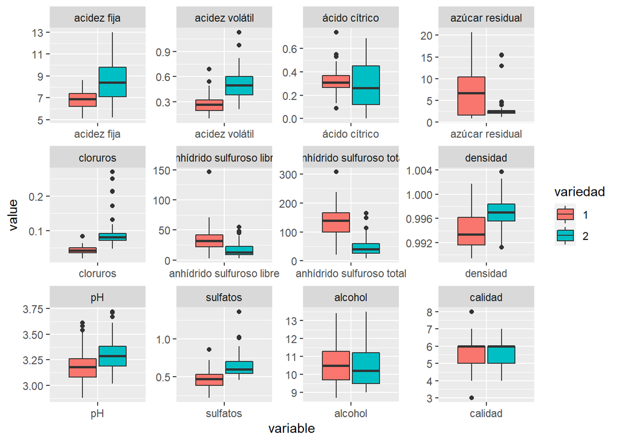

```r
ggplot(data_long, aes(x=variable, y=value, fill= variedad)) +
    geom_boxplot() +
    facet_wrap(~variable, scale="free")
```

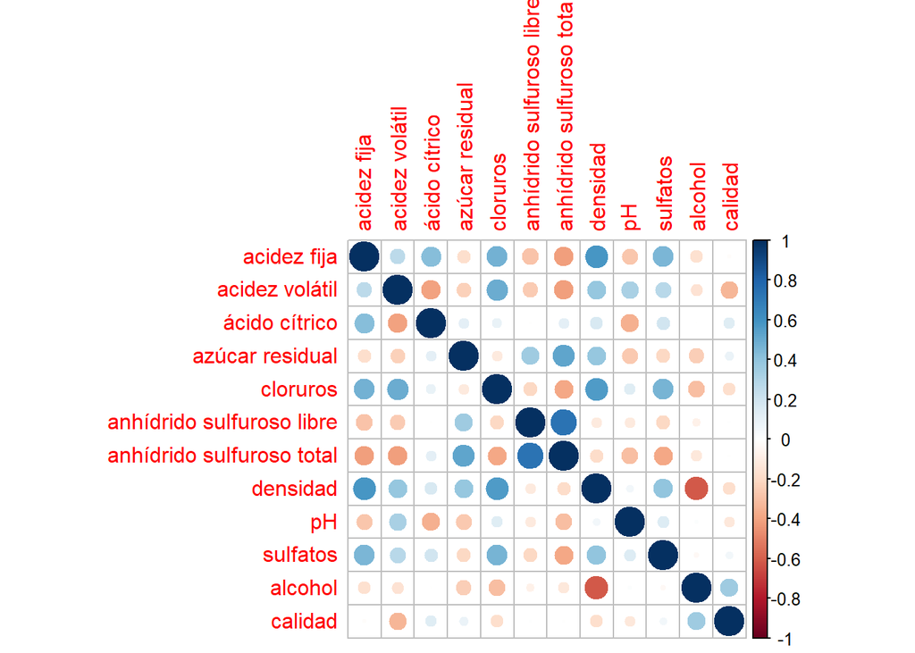

```r
#Matriz de correlación
m_cor <- cor(df_numericas)

# representa la matriz de correlaciones mediante círculos
corrplot(m_cor,method="circle")
```

## Cálculo de la varianza

```r
variance <- df_vinos %>%
  summarise_if(is.numeric, var) %>%
  t() %>%
  data.frame() %>%
  rename( "varianza"=".") %>%
  round(3)

variance
```

|  | varianza |
| --- | --- |
| acidez fija | 2.464 |
| acidez volátil | 0.031 |
| ácido cítrico | 0.023 |
| azúcar residual | 22.911 |
| cloruros | 0.001 |
| anhídrido sulfuroso libre | 301.228 |
| anhídrido sulfuroso total | 3270.552 |
| densidad | 0.000 |
| pH | 0.026 |
| sulfatos | 0.022 |

[output cut: 2 more lines]

# PCA

```r
pca <- prcomp(df_numericas,scale = TRUE)# con datos estandarizados
names(pca)
```

```
## [1] "sdev"     "rotation" "center"   "scale"    "x"
```

`center`:contienen la media de las variables previa estandarización (en la escala original)

`scale`: contienen desviación típica de las variables previa estandarización (en la escala original)

`rotation`: contiene los *loadings*

## Cargas o *loadings*

```r
knitr::kable(round(pca$rotation,2))
```

|  | PC1 | PC2 | PC3 | PC4 | PC5 | PC6 | PC7 | PC8 | PC9 | PC10 | PC11 | PC12 |
| --- | --- | --- | --- | --- | --- | --- | --- | --- | --- | --- | --- | --- |
| acidez fija | 0.37 | -0.22 | 0.33 | -0.19 | 0.05 | 0.23 | -0.07 | -0.03 | -0.50 | -0.23 | 0.36 | -0.42 |
| acidez volátil | 0.36 | 0.12 | -0.33 | 0.01 | 0.02 | 0.49 | 0.19 | 0.06 | -0.20 | 0.60 | -0.25 | -0.08 |
| ácido cítrico | 0.02 | -0.32 | 0.49 | -0.12 | 0.24 | -0.43 | 0.23 | 0.28 | -0.12 | 0.39 | -0.32 | 0.01 |
| azúcar residual | -0.18 | -0.45 | -0.14 | 0.30 | -0.42 | 0.04 | 0.49 | 0.00 | 0.13 | -0.11 | -0.10 | -0.45 |
| cloruros | 0.41 | -0.14 | -0.06 | 0.11 | 0.18 | 0.11 | -0.10 | 0.64 | 0.53 | -0.15 | 0.14 | -0.04 |
| anhídrido sulfuroso libre | -0.30 | -0.26 | -0.20 | 0.24 | 0.56 | 0.25 | -0.16 | 0.08 | -0.27 | -0.32 | -0.40 | 0.01 |
| anhídrido sulfuroso total | -0.39 | -0.32 | -0.16 | 0.03 | 0.27 | 0.08 | 0.01 | 0.00 | 0.03 | 0.43 | 0.67 | 0.07 |
| densidad | 0.35 | -0.42 | -0.13 | 0.19 | -0.23 | -0.06 | 0.10 | -0.05 | -0.26 | -0.13 | 0.08 | 0.70 |
| pH | 0.14 | 0.32 | -0.33 | 0.43 | 0.13 | -0.56 | 0.08 | 0.19 | -0.36 | -0.01 | 0.20 | -0.22 |
| sulfatos | 0.34 | -0.04 | 0.20 | 0.40 | 0.39 | -0.04 | 0.09 | -0.63 | 0.33 | 0.06 | 0.01 | -0.07 |
| alcohol | -0.16 | 0.39 | 0.34 | 0.17 | 0.14 | 0.30 | 0.63 | 0.18 | -0.07 | -0.20 | 0.17 | 0.24 |
| calidad | -0.13 | 0.05 | 0.42 | 0.62 | -0.31 | 0.18 | -0.45 | 0.15 | -0.10 | 0.24 | -0.02 | 0.01 |

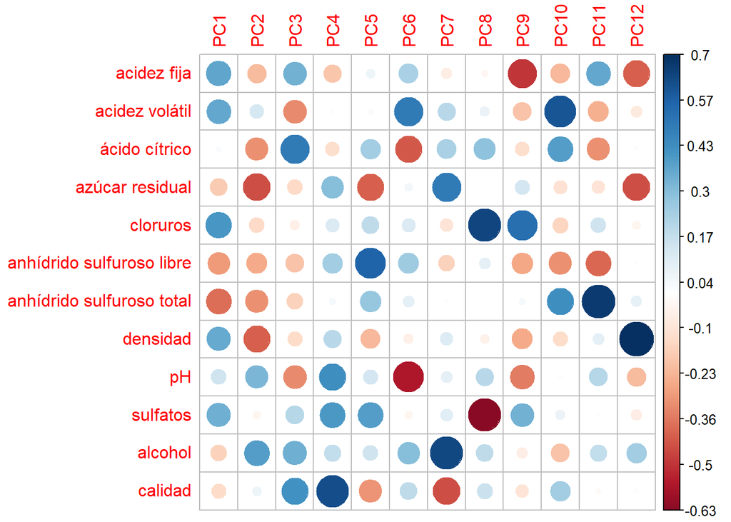

```r
contrib <- as.matrix(round(pca$rotation,2))
corrplot(contrib,is.corr=FALSE)
```

```r
knitr::kable(round(pca$center,2)) #vector de medias
```

|  | x |
| --- | --- |
| acidez fija | 7.68 |
| acidez volátil | 0.39 |
| ácido cítrico | 0.31 |
| azúcar residual | 4.81 |
| cloruros | 0.07 |
| anhídrido sulfuroso libre | 25.08 |
| anhídrido sulfuroso total | 90.27 |
| densidad | 1.00 |
| pH | 3.24 |
| sulfatos | 0.55 |
| alcohol | 10.50 |
| calidad | 5.75 |

## Autovalores

¿Qué proporción de la variabilidad total es explicada por cada una de las componentes?

```r
prop_varianza <- pca$sdev^2 / sum(pca$sdev^2)
prop_varianza
```

```
##  [1] 0.293684467 0.193622683 0.155900023 0.081871900 0.069569847 0.058249895
##  [7] 0.041146394 0.037547043 0.032608558 0.021614427 0.010891515 0.003293247
```

```r
prop_varianza_acum <- cumsum(prop_varianza)
prop_varianza_acum
```

```
##  [1] 0.2936845 0.4873072 0.6432072 0.7250791 0.7946489 0.8528988 0.8940452
##  [8] 0.9315923 0.9642008 0.9858152 0.9967068 1.0000000
```

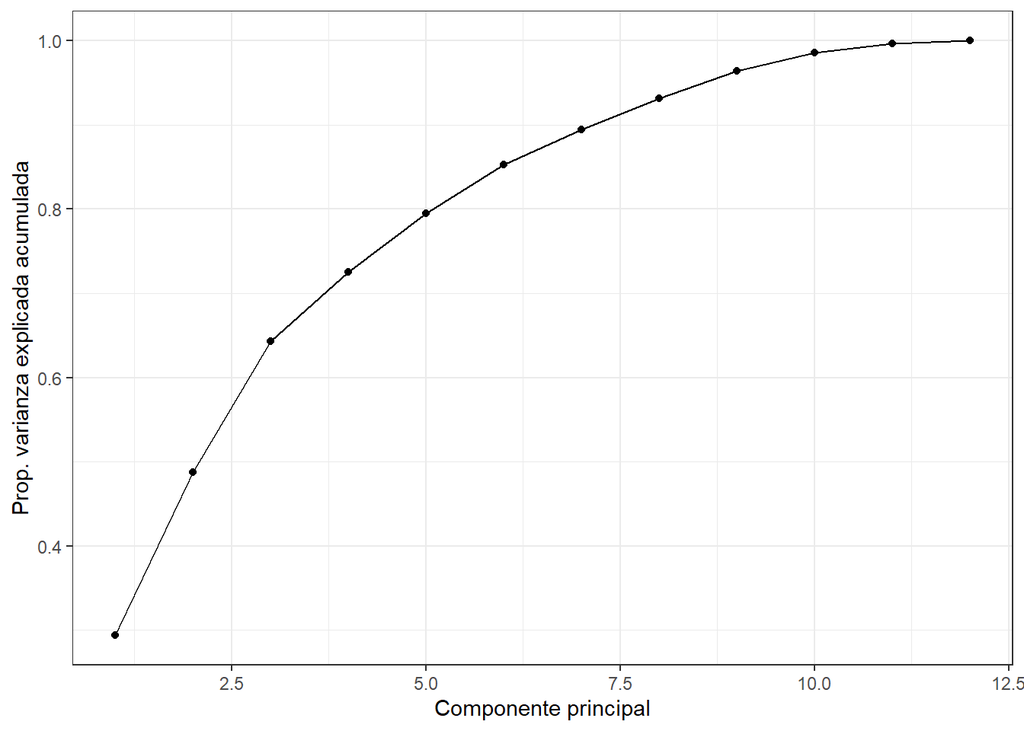

```r
ggplot(data = data.frame(prop_varianza_acum, pc = 1:12),
       aes(x = pc, y = prop_varianza_acum, group = 1)) +
  geom_point() +
  geom_line() +
  theme_bw() +
  labs(x = "Componente principal",
       y = "Prop. varianza explicada acumulada")
```

# ¿Cuántas CPs elegir?

## Criterio 1: Porcentaje de variabilidad explicada

Se define un porcentaje de variabilidad mínimo que se desea explicar y se toman las primeras *m* componentes que alcanzan este porcentaje de explicación.

Por ejemplo se elige un porcentaje de 90% de variabilidad.

```r
round(prop_varianza_acum*100,2)# llevo datos a porcentaje
```

```
##  [1]  29.37  48.73  64.32  72.51  79.46  85.29  89.40  93.16  96.42  98.58
## [11]  99.67 100.00
```

## Criterio 2: Criterio de Kaiser

Consiste en retener las *m* primeras componentes tales que sus autovalores resulten iguales o mayores que 1.

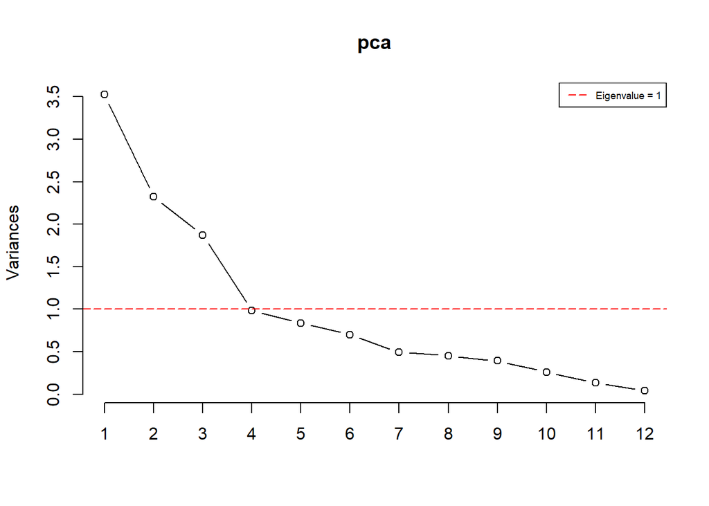

```r
screeplot(pca, type = "l", npcs = 12)
abline(h = 1, col="red", lty=5)
legend("topright", legend=c("Eigenvalue = 1"),
       col=c("red"), lty=5, cex=0.6)
```

## Criterio 3: Criterio del bastón roto

Si la proporción de variabilidad explicada por $Y1, Y2, · · ·, Ym$ se estabiliza a partir de un cierto valor de CP, entonces aumentar la dimensión no aportaría cambios significativos.

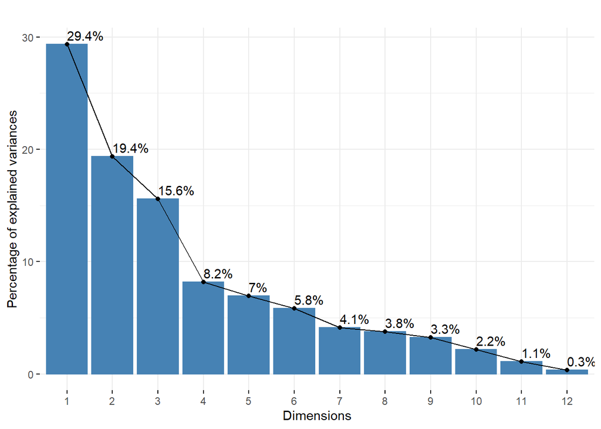

```r
fviz_eig(pca, ncp =12, addlabels = TRUE, main="")
```

# Biplot

- Los n objetos son ordenados en función de su puntaje en cada uno de los componentes analizados
- Las p variables son representadas como vectores

## *Scores*

Se estandarizan las variables originales y luego con la fórmula de la combinación lineal correspondiente para cada CP, se calculan los *scores* o puntajes de los vinos.

```r
pca$x[,1]# scores para la primer componente (PC1)
```

```
##   [1] -2.06986035 -1.41843947 -1.39666773 -1.70299656 -3.17706141 -1.29777758
##   [7] -1.37471535 -1.01610935 -0.52000942 -1.67167162 -3.00227400 -1.60650091
##  [13] -1.47977234 -1.91635977 -1.49564197 -2.36175849 -1.35810930 -1.84911116
##  [19] -1.76149290 -2.64772320 -1.74350162 -0.85315282 -1.71360309 -1.59635078
##  [25] -2.72361416 -2.83836160 -2.23419053 -0.99724836 -2.40090498 -1.84861073
##  [31] -1.12949718 -1.37936546 -1.09639296 -2.09131141 -1.41120551 -4.01362424
##  [37] -2.13434114 -2.06816830 -2.36310374 -1.14215899 -1.19210295 -1.35149522
##  [43] -1.46329716 -2.50451334 -0.28052554 -1.77710393 -1.03037576 -1.39570428
##  [49] -2.15199375 -2.28734811 -1.55272899 -2.52808988 -1.16657350 -0.66740388
##  [55] -1.73309872 -0.00217333 -0.82626834 -1.73517816 -1.83211789 -1.68420911
##  [61] -0.35455206 -0.96867870 -0.76600420 -1.39521686 -1.58095528 -2.17022131
##  [67] -1.31655136 -0.44185866 -1.64904269 -1.82473029 -1.38194126 -1.06658363
##  [73] -1.93292472 -1.79883259 -0.74127783 -1.81600637 -2.39360783 -1.69591135
##  [79] -1.53184645 -2.42634310  0.43439764 -0.95149232 -1.31317593 -1.83198963
##  [85] -1.92060878 -1.77316258 -1.71740885 -1.67168619 -1.21918381 -2.52977636
```

[output cut: 19 more lines]

*Scores* para todas las CPs.

```r
res.ind <- get_pca_ind(pca)
knitr::kable(head(res.ind$coord,10), format = "html") %>%
  kableExtra::kable_styling() %>%
  kableExtra::scroll_box(width = "100%")
```

| Dim.1 | Dim.2 | Dim.3 | Dim.4 | Dim.5 | Dim.6 | Dim.7 | Dim.8 | Dim.9 | Dim.10 | Dim.11 | Dim.12 |
| --- | --- | --- | --- | --- | --- | --- | --- | --- | --- | --- | --- |
| -2.0698603 | -3.2737123 | 0.1605758 | 0.8915083 | -0.7594625 | 0.5662528 | -0.8971379 | 0.0093456 | 0.2594276 | 0.3963524 | -0.1602143 | 0.1117061 |
| -1.4184395 | 0.6349382 | 0.0497278 | 0.2930393 | 0.3404217 | -1.4997095 | -0.2576467 | 0.0004010 | -0.7663770 | 0.4143392 | 1.0497194 | -0.1101565 |
| -1.3966677 | -0.7681746 | -0.9024310 | 0.0194631 | 0.0009243 | 0.6051373 | -0.6011904 | 0.3238809 | -0.2842107 | 0.3301607 | 0.3231356 | -0.0927639 |
| -1.7029966 | -0.0711534 | 0.0849246 | 0.5996387 | 0.0183202 | 0.0168004 | 0.6946141 | -0.1168903 | 0.5585325 | 0.3769094 | 0.6900362 | -0.2411656 |
| -3.1770614 | 0.4452532 | 1.7143983 | 1.1716666 | -1.2443236 | 1.5254802 | -0.2273164 | 0.7133960 | -0.3461548 | -0.1599372 | -0.0189315 | -0.0027948 |
| -1.2977776 | 0.5250828 | 0.0725457 | 0.0026809 | 0.2631057 | -1.6014183 | -0.9366791 | -0.0804245 | -0.1435848 | 0.1215825 | 0.0323260 | 0.0248339 |
| -1.3747154 | 0.7120952 | 2.3105414 | 0.4755407 | 0.6655531 | 0.3848945 | -0.9392998 | -1.0325967 | 0.5237114 | -0.1281841 | -0.0741077 | -0.2518821 |
| -1.0161093 | 0.3127643 | -2.0798342 | 0.2738927 | -0.7052338 | 1.3930648 | -0.1644444 | 0.1178842 | -0.4886069 | 1.0281044 | -0.0447646 | -0.1629992 |
| -0.5200094 | -3.2062795 | -1.8165431 | -0.0213877 | -1.5454342 | -0.3348065 | 0.5553421 | 0.3026647 | 0.3001734 | -0.9095976 | 0.2234904 | -0.0243995 |
| -1.6716716 | -1.0928509 | 0.1441054 | 0.4560230 | 0.6109846 | -0.9677610 | -0.0843900 | 0.3339740 | 0.0452507 | 0.3763510 | -0.2744215 | 0.0067730 |

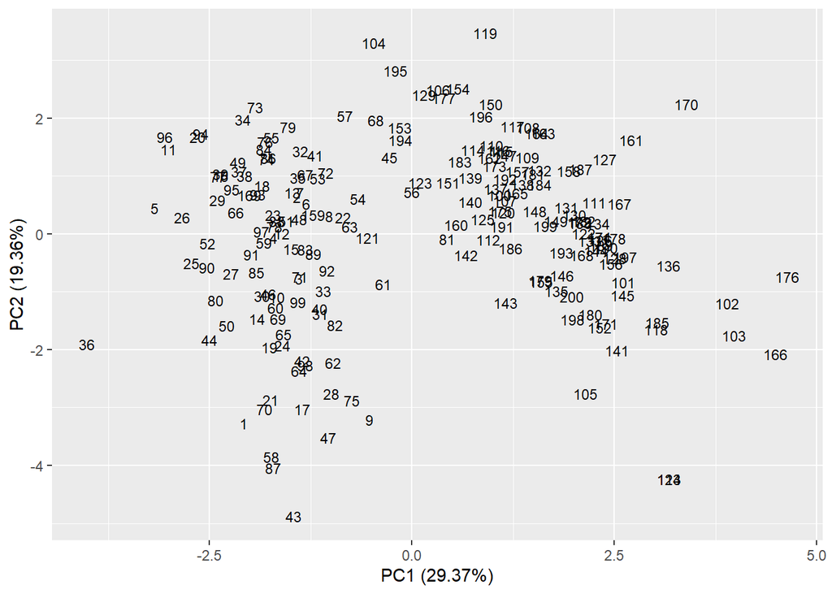

```r
library(ggfortify)
autoplot(pca, data = df_vinos, shape = F, label.size = 3, scale = 0)# scale=0 biplot segun scores
```

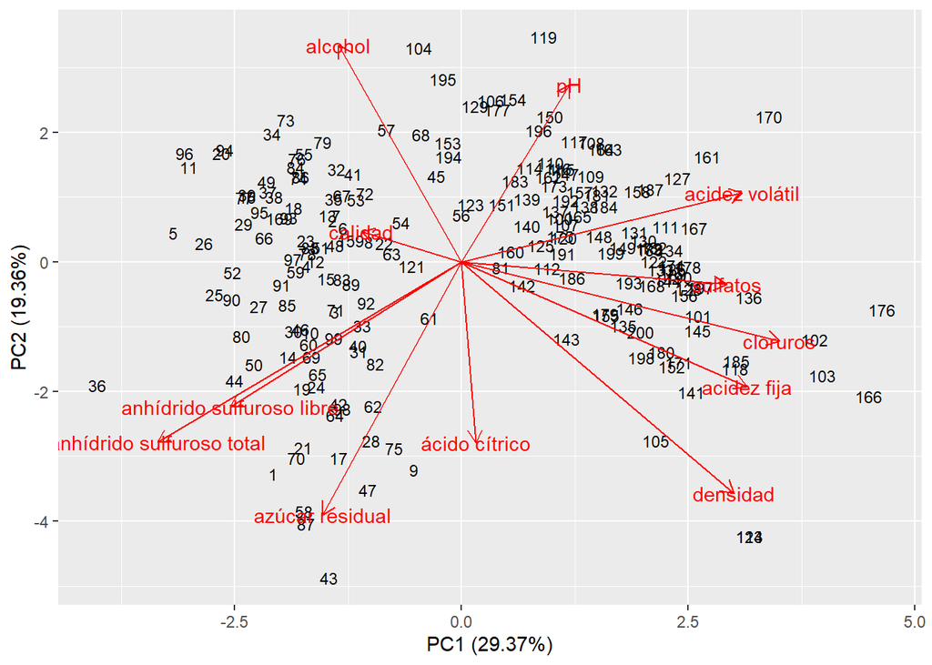

```r
autoplot(pca,
         data = df_vinos,
         shape = F,
         label.size = 3,
         scale = 0, # scale=0 biplot segun scores
         loadings.label=T,# nombre de las variables
         loadings=T)# variables como vectores
```

Y si se diferencia a cada punto según la variedad de vino?

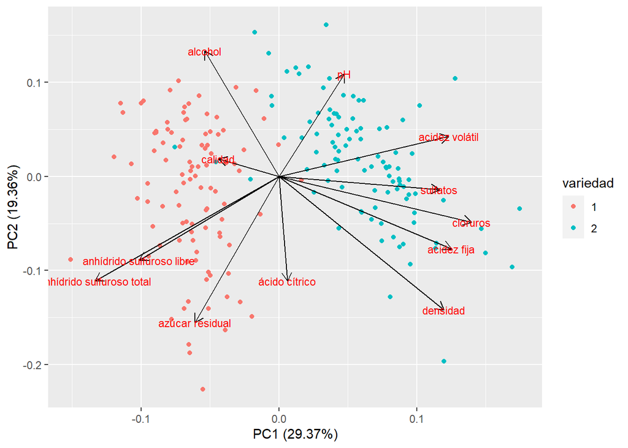

```r
autoplot(pca,
         data = df_vinos,
         colour = 'variedad',
         loadings = TRUE,
         loadings.colour = 'black',
         loadings.label = TRUE,
         loadings.label.size = 3)
```

## ¿Qué información podemos sacar del biplot? 🤔

Tener en cuenta lo siguiente:

- Si se es el/la experto/a de dominio (o se le puede consultar) se puede dar una interpretación a qué aspecto del tema se refiere PC1 y PC2, considerando los *loadings* de las varibles originales.
- Si dos variables forman ángulos pequeños; esto nos estaría diciendo que las variables están muy correlacionadas (en este ejemplo sería el caso de anhídrico sulfuroso libre y anhídrico sulfuroso total)
- Si dos variables forman ángulos de 90°, entonces nos indica que ambas variables **no** están correlacionadas (por ejemplo pH y densidad).
- Los resultados del PCA son sensibles a la presencia de *outliers* por lo que pueden distorsionar el ordenamiento.

## ¿Y si se quiere graficar el PC2 vs PC3?

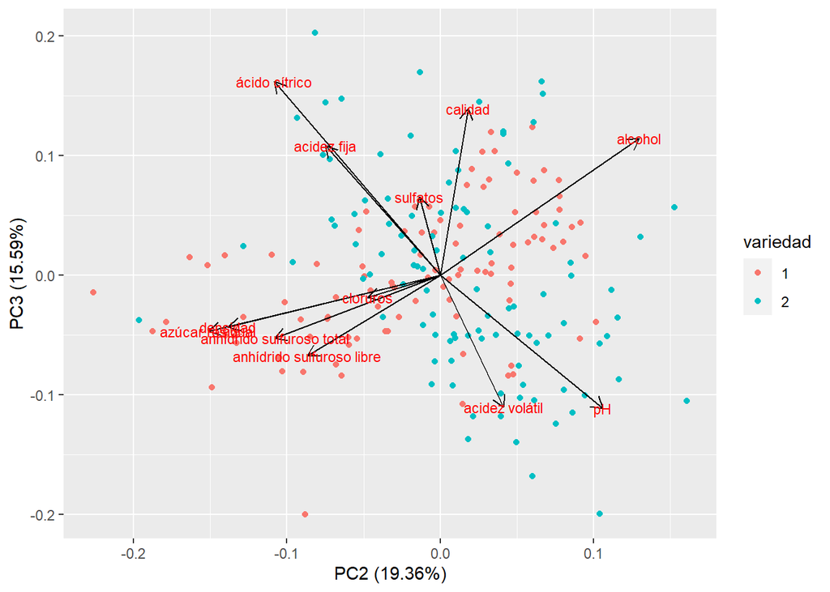

```r
autoplot(pca, x = 2, y = 3,
         data = df_vinos,
         colour = 'variedad',
         loadings = TRUE,
         loadings.colour = 'black',
         loadings.label = TRUE,
         loadings.label.size = 3)
```

# En Python

En [este link](https://github.com/PamelaPairo/maestria_DM/blob/main/AID/PCA/02_PCA%20en%20Python.ipynb) se puede ver el código en Python para realizar PCA.